# Red_Wine_DataAnalysis

Sridhar Varanasi

January 20, 2018

## 0.1 R Markdown

```
## [1] 1599   13
```

```
##  [1] "X"                    "fixed.acidity"        "volatile.acidity"
##  [4] "citric.acid"          "residual.sugar"       "chlorides"
##  [7] "free.sulfur.dioxide"  "total.sulfur.dioxide" "density"
## [10] "pH"                   "sulphates"            "alcohol"
## [13] "quality"
```

- This data set contains 13 variables and 1599 observations of red wines.
- The first column of this dataset is an identity column which has uniques value to each of the records.
- All the columns are either numeric or of integer types.
- There are variables like acicity , citric acid content, residual sugar, Suplphates ,alcohol content, pH value that determine the quality of red wine.
- The rating for quality of wine is between 0 to 10 . 0 being lowest and 10 being highest.
- In this analysis I will be starting off with doing univariate analysis. Then I wil proceed with Bivariate and Multivariate analysis on the data.
- Let’s load the data and check the structure and summary of each variable in the dataset.

```
## 'data.frame':    1599 obs. of  13 variables:
##  $ X                   : int  1 2 3 4 5 6 7 8 9 10 ...
##  $ fixed.acidity       : num  7.4 7.8 7.8 11.2 7.4 7.4 7.9 7.3 7.8 7.5 ...
##  $ volatile.acidity    : num  0.7 0.88 0.76 0.28 0.7 0.66 0.6 0.65 0.58 0.5 ...
##  $ citric.acid         : num  0 0 0.04 0.56 0 0 0.06 0 0.02 0.36 ...
##  $ residual.sugar      : num  1.9 2.6 2.3 1.9 1.9 1.8 1.6 1.2 2 6.1 ...
##  $ chlorides           : num  0.076 0.098 0.092 0.075 0.076 0.075 0.069 0.065 0.073 0.071 ...
##  $ free.sulfur.dioxide : num  11 25 15 17 11 13 15 15 9 17 ...
##  $ total.sulfur.dioxide: num  34 67 54 60 34 40 59 21 18 102 ...
##  $ density             : num  0.998 0.997 0.997 0.998 0.998 ...
##  $ pH                  : num  3.51 3.2 3.26 3.16 3.51 3.51 3.3 3.39 3.36 3.35 ...
##  $ sulphates           : num  0.56 0.68 0.65 0.58 0.56 0.56 0.46 0.47 0.57 0.8 ...
##  $ alcohol             : num  9.4 9.8 9.8 9.8 9.4 9.4 9.4 10 9.5 10.5 ...
##  $ quality             : int  5 5 5 6 5 5 5 7 7 5 ...
```

```
##        X          fixed.acidity   volatile.acidity  citric.acid
##  Min.   :   1.0   Min.   : 4.60   Min.   :0.1200   Min.   :0.000
##  1st Qu.: 400.5   1st Qu.: 7.10   1st Qu.:0.3900   1st Qu.:0.090
##  Median : 800.0   Median : 7.90   Median :0.5200   Median :0.260
##  Mean   : 800.0   Mean   : 8.32   Mean   :0.5278   Mean   :0.271
##  3rd Qu.:1199.5   3rd Qu.: 9.20   3rd Qu.:0.6400   3rd Qu.:0.420
##  Max.   :1599.0   Max.   :15.90   Max.   :1.5800   Max.   :1.000
##  residual.sugar     chlorides       free.sulfur.dioxide
##  Min.   : 0.900   Min.   :0.01200   Min.   : 1.00
##  1st Qu.: 1.900   1st Qu.:0.07000   1st Qu.: 7.00
##  Median : 2.200   Median :0.07900   Median :14.00
##  Mean   : 2.539   Mean   :0.08747   Mean   :15.87
##  3rd Qu.: 2.600   3rd Qu.:0.09000   3rd Qu.:21.00
##  Max.   :15.500   Max.   :0.61100   Max.   :72.00
##  total.sulfur.dioxide    density             pH          sulphates
##  Min.   :  6.00       Min.   :0.9901   Min.   :2.740   Min.   :0.3300
##  1st Qu.: 22.00       1st Qu.:0.9956   1st Qu.:3.210   1st Qu.:0.5500
##  Median : 38.00       Median :0.9968   Median :3.310   Median :0.6200
##  Mean   : 46.47       Mean   :0.9967   Mean   :3.311   Mean   :0.6581
##  3rd Qu.: 62.00       3rd Qu.:0.9978   3rd Qu.:3.400   3rd Qu.:0.7300
##  Max.   :289.00       Max.   :1.0037   Max.   :4.010   Max.   :2.0000
##     alcohol         quality
##  Min.   : 8.40   Min.   :3.000
##  1st Qu.: 9.50   1st Qu.:5.000
##  Median :10.20   Median :6.000
##  Mean   :10.42   Mean   :5.636
##  3rd Qu.:11.10   3rd Qu.:6.000
##  Max.   :14.90   Max.   :8.000
```

# 1 Univariate Analysis

**Let’ check the distribution of the variables using histograms and boxplots**

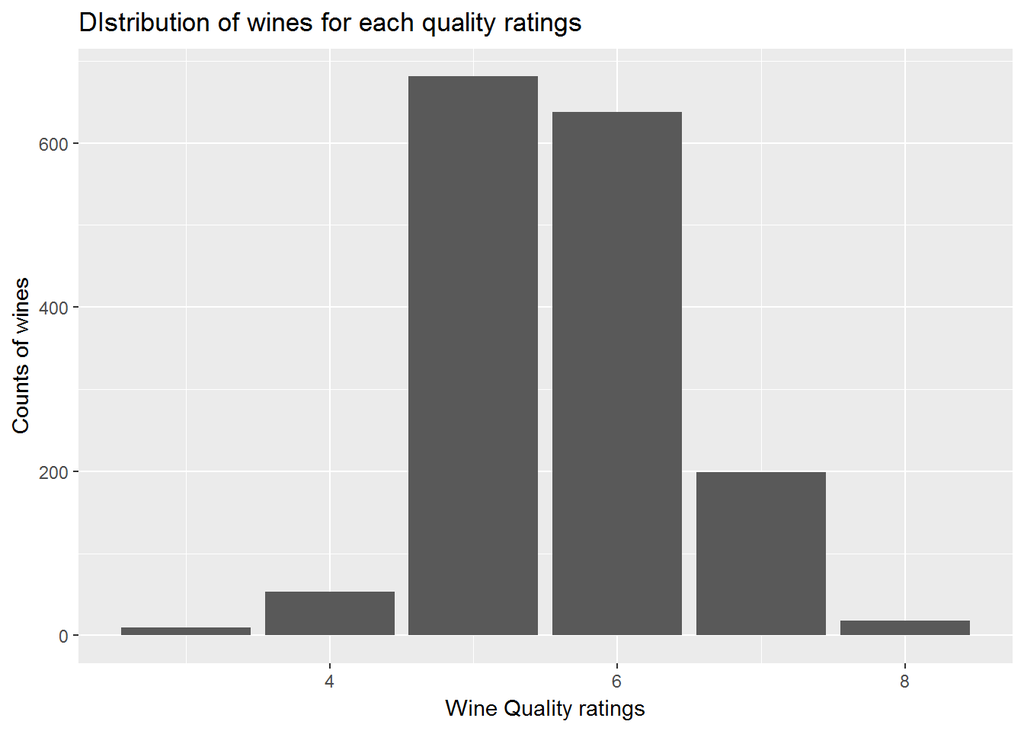

```
##
##   3   4   5   6   7   8
##  10  53 681 638 199  18
```

- The lowest wine rating is 3 in this data set and the highest rating in the dataset is 8.
- Almost 1300 of the 1599 wines in the dataset are having quality ratings as 5 or 6.
- There are 10 and 18 wines in the dataset that have rating of 3 and 8 respectively.

```
##
##    Low Medium   Good
##     63    681    855
```

Added a variable quality_category which has 3 categories ‘Low’,‘Medium’ and ‘Good’ based on the quality ratings.

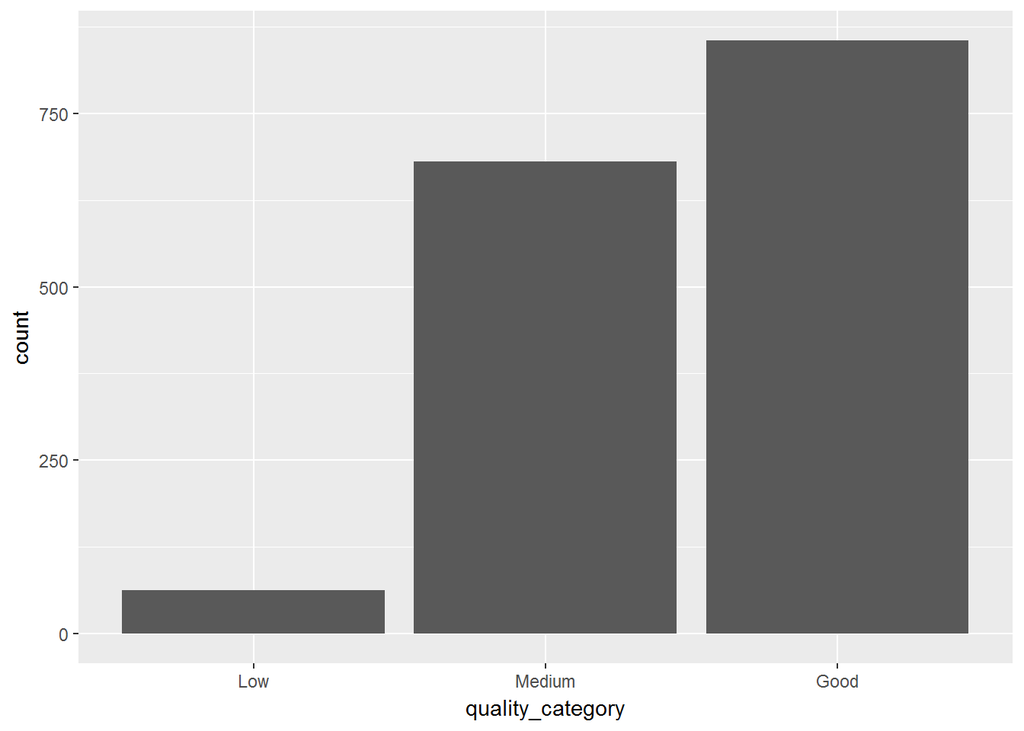

- As seen from above graph most of the wines are unser the Good category followed by Medium and Low.
- We will further analyze relationsheip with other variables for each of the categories in the bi-variate section.

**Let’s have a look at the ph content ditribution in the dataset**

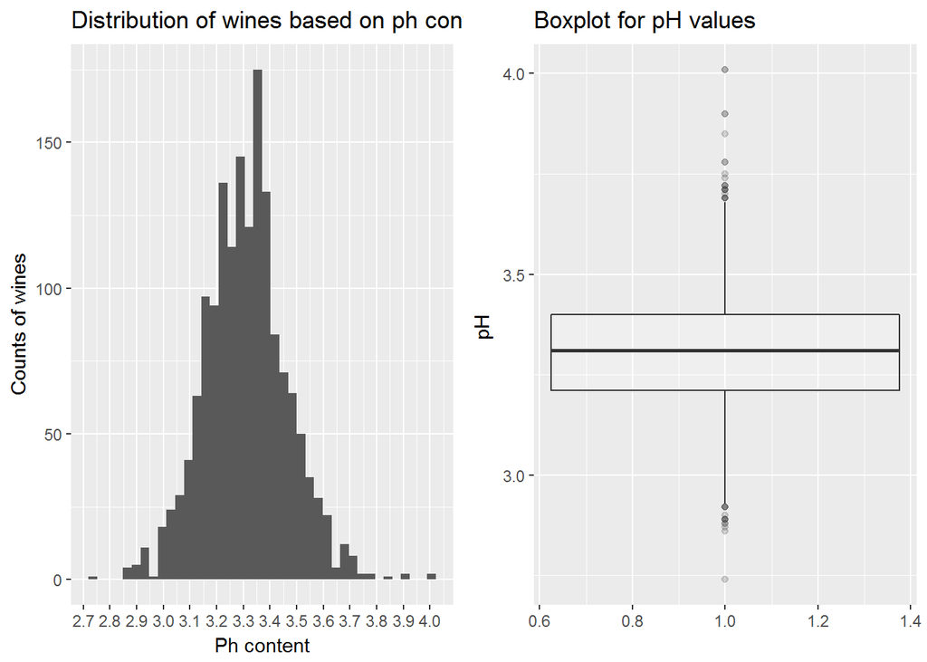

- Most of the wines are having Ph values less than 3.5. Only a few wines are having ph content above 3.5. Overall the distribution looks normal. Let’s have a look at the density of wines.
- There are few wines which have pH as low as 2.7 and few wines which have pH value as high as 4.0.
- Also there are a few outliers which can be seen in the boxplot.

**Note**:The lower the pH value the more acidic the wine is.

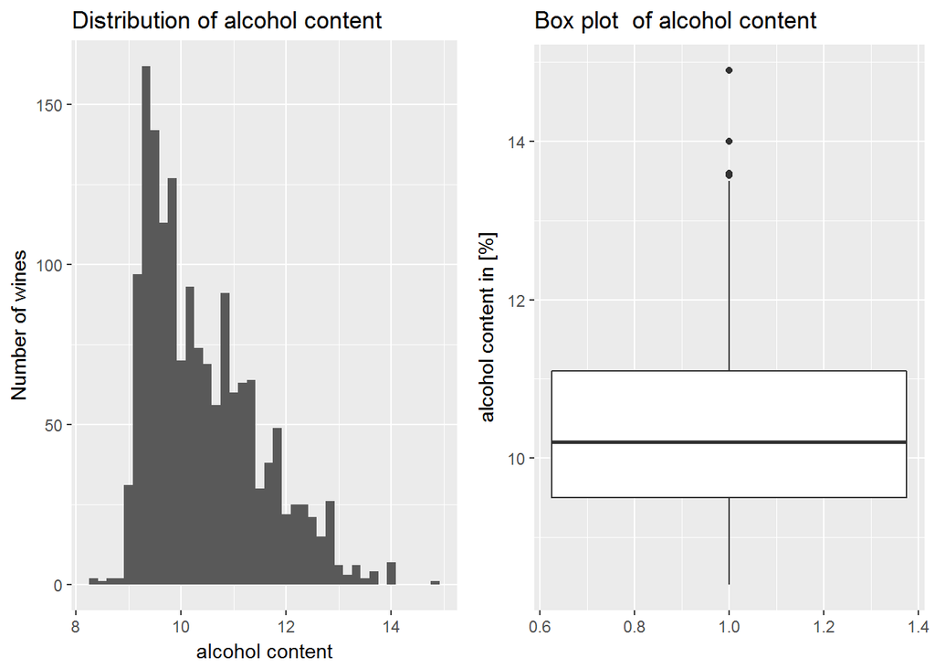

```
##    Min. 1st Qu.  Median    Mean 3rd Qu.    Max.
##    8.40    9.50   10.20   10.42   11.10   14.90
```

- As seen from the histogram for alcohol content most of the wines have alcohol content less than 12%. Also there are only few outliers for alcohol content.
- The range of alcohol content is between 8.40 to 14.90 with median value of 10.20.
- Let’s look at the density avriable of red wine.

[figure not shown]

```
##    Min. 1st Qu.  Median    Mean 3rd Qu.    Max.
##  0.9901  0.9956  0.9968  0.9967  0.9978  1.0037
```

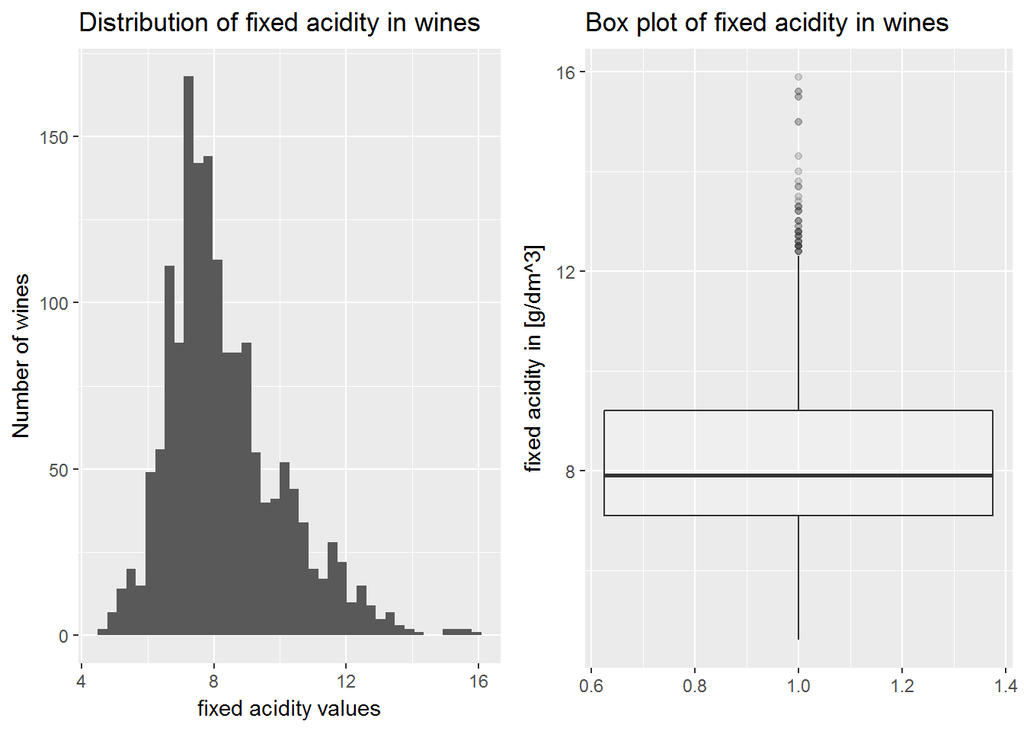

```
##    Min. 1st Qu.  Median    Mean 3rd Qu.    Max.
##    4.60    7.10    7.90    8.32    9.20   15.90
```

- It can be seen that most of the wines have fixed acidity around 6-10 g / dm^3. There are a few wines in the data whose acidity levels are around 16
- The distribution of the fixed acidity is positively skewed as seen in above
- The minumum vaue for fixed acidity is 4.60 and the maximum is 15.90 with median fixed acidity at 7.90
- There are many outliers which can be seen from the box plot

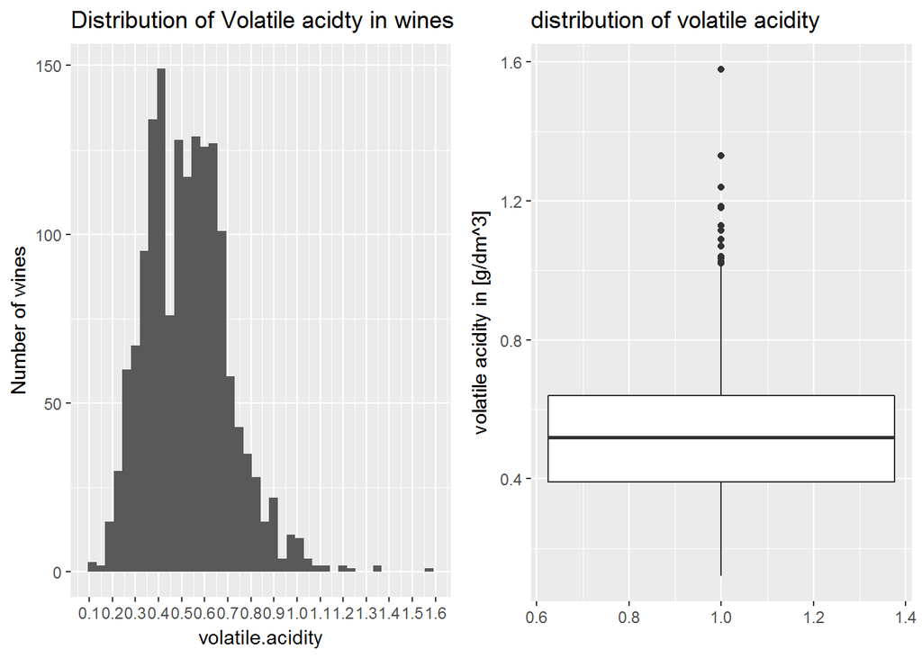

```
##    Min. 1st Qu.  Median    Mean 3rd Qu.    Max.
##  0.1200  0.3900  0.5200  0.5278  0.6400  1.5800
```

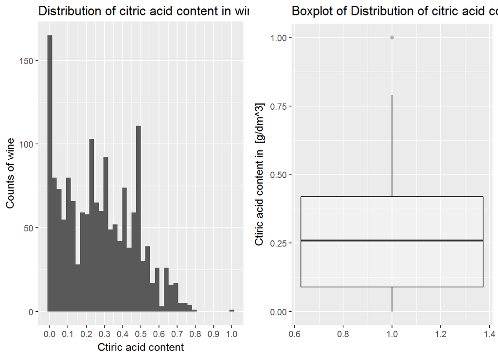

```
##    Min. 1st Qu.  Median    Mean 3rd Qu.    Max.
##   0.000   0.090   0.260   0.271   0.420   1.000
```

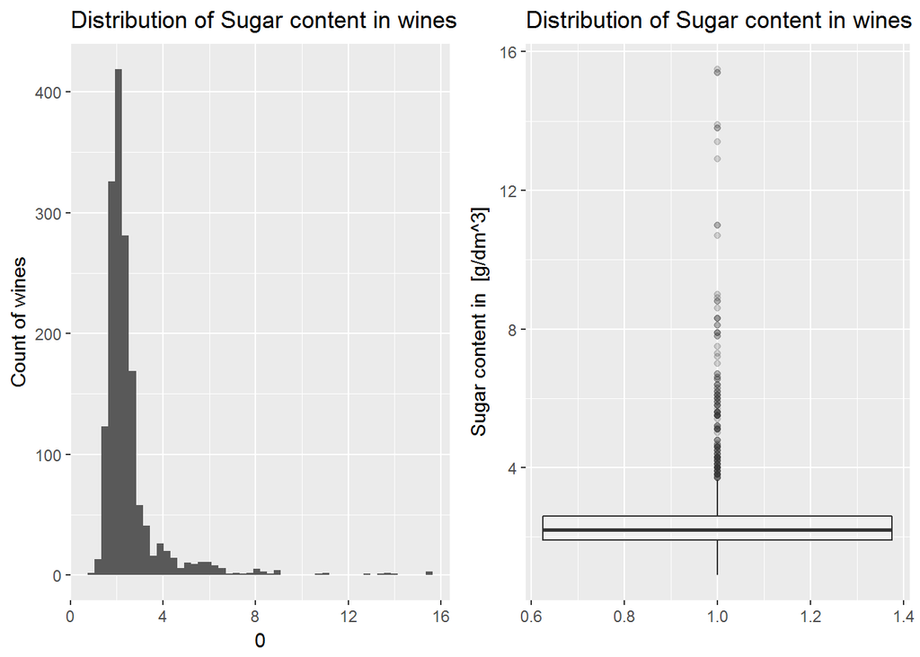

```
##    Min. 1st Qu.  Median    Mean 3rd Qu.    Max.
##   0.900   1.900   2.200   2.539   2.600  15.500
```

```
##
##   2 2.2 1.8 2.1 1.9 2.3 2.4 2.5 2.6 1.7 1.6 2.8 2.7 1.4 1.5   3 2.9 3.2
## 156 131 129 128 117 109  86  84  79  76  58  49  39  35  30  25  24  15
## 3.4 3.3   4 1.2 3.6 3.8 4.3 5.5 3.1 3.9 4.1 4.6
##  15  11  11   8   8   8   8   8   7   6   6   6
```

- As the description explains the relevance of sugar content. It says that most of the wines have sugar content between 1 gm/litre to 45 gm/litre. The same can be seen in the distribution also. Most of the wines have sugar content less than 4 gm/litre. Ditribution of sugar content is mostly right skewed.
- There are many outliers for residual sugar in the dataset.
- The range of residual sugar is between 0.9 to 15.50 with a median value of 2.2

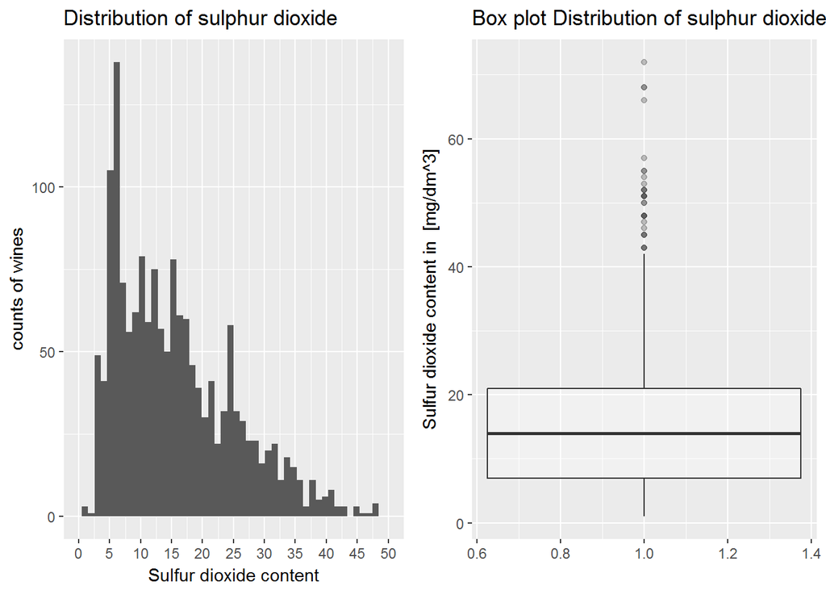

```
##    Min. 1st Qu.  Median    Mean 3rd Qu.    Max.
##    1.00    7.00   14.00   15.87   21.00   72.00
```

- There are More number of wines with sulphur dioxide content less than 20. In the histogram graph I have eleiminated the outliers and have shown ponly the top 99 percentile of data
- Since the higher the content of sulphur dioxide , the better it is for wine as it prevents oxidation of wine and acts as anti microbial
- I think this variable will have impact on the prediction of wine quality
- From the box plot above it can be seen that there are many outliers in the data for this variable
- Also the range for this variable is quite high as it ranges from a min. value of 1 to a maximum value of 72 with a median value of 14

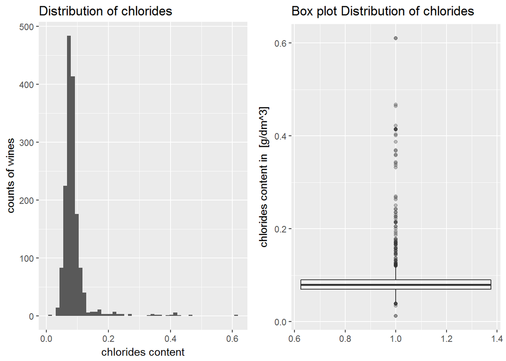

```
##    Min. 1st Qu.  Median    Mean 3rd Qu.    Max.
## 0.01200 0.07000 0.07900 0.08747 0.09000 0.61100
```

- The chloride content for most of the wines in the dataset is below 0.2 .
- Also from the boxplot it can be seen that there are quite many outliers.
- The range of values for chlorides variable is betwen 0.012 to 0.6110 with a median value of 0.079.

```
##  [1] "X"                    "fixed.acidity"        "volatile.acidity"
##  [4] "citric.acid"          "residual.sugar"       "chlorides"
##  [7] "free.sulfur.dioxide"  "total.sulfur.dioxide" "density"
## [10] "pH"                   "sulphates"            "alcohol"
## [13] "quality"              "quality_category"
```

## 1.1 What is the structure of your dataset?

**Few observations about the data**

- Most of the wines are of average quality.
- This dataset contains data about only a sample of red wines.
- It can be seen that pH , Density are normally distributed.
- Looking at variables like alcohol content, fixed acidity, volatile acidity, residual sugar content,sulphur dioxide and chloride content are positively skewed.

## 1.2 What is/are the main feature(s) of interest in your dataset?

- The main feature of interest for this dataset is the wine quality.
- I want to find out what all variables impact the wine quality. From the above univariate analysis I think that pH,sulphates contet and alcohol directly impact the quality of the wines.
- In the multivariate analysis I will try to find out if any more variables can be used to predict the quality of wine.

## 1.3 What other features in the dataset do you think will help support your investigation into your feature(s) of interest?

- Apart from pH, sulpahates and alcohol content which play a major role in determining the quality of red wine. Variables like acidity(fixed and volatile) and sugar content can also play an important role in predicting the quality rating.
- I can say this by looking at the similarity of distribution of quality and acidity(fixed and volatile) ,residual sugar content.

## 1.5 Of the features you investigated, were there any unusual distributions? Did you perform any operations on the data to tidy, adjust, or change the form of the data? If so, why did you do this?

- There were few variables like fixed acidity , colatile acidity , residual sugar content which were marginally right skewed.
- I haven’t done any specific transformations to the data apart from adding a new variable.

# 2 Bivariate analysis

**We will be further checking on the relationships between each of the variables with quality variable in the Bi variate analysis**

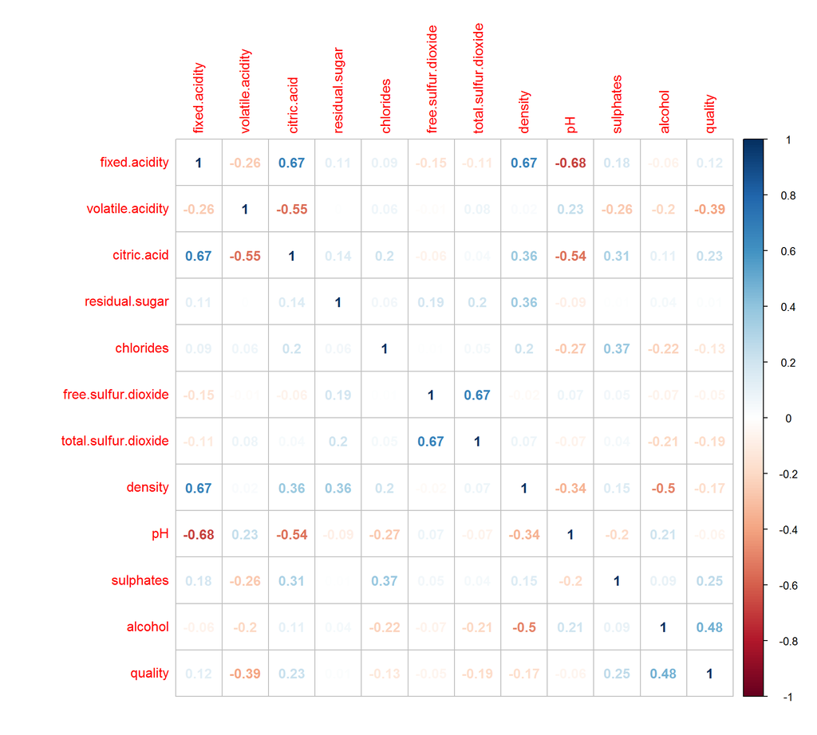

**From the above correltion plot following are my observations about correaltion pf other variables with quality variable:**

- quality has moderately negative correlation with volatile acidity
- quality has moderately positive correlation with alcohol content
- quality has weak positive correlation with sulphate content
- quality has weak positive correlation with citric acid

**Let’s check if there is any correlation amongst the other variables themselves:**

- Fixed acidity and citric acid have nearly strong correlation between them
- Fixed acidity has nearly strong correlation with density
- Fixed acidity has a negative correlation with pH value which is obvious because lesser the pH value higher the acid strength
- Citric acid has a moderately negative correlation with volatile acidity and pH
- Free sulfur dioxide and total sulfur dioxide have a positive correlation with each other.
- Chloride has a moderately positive correlation with sulphate

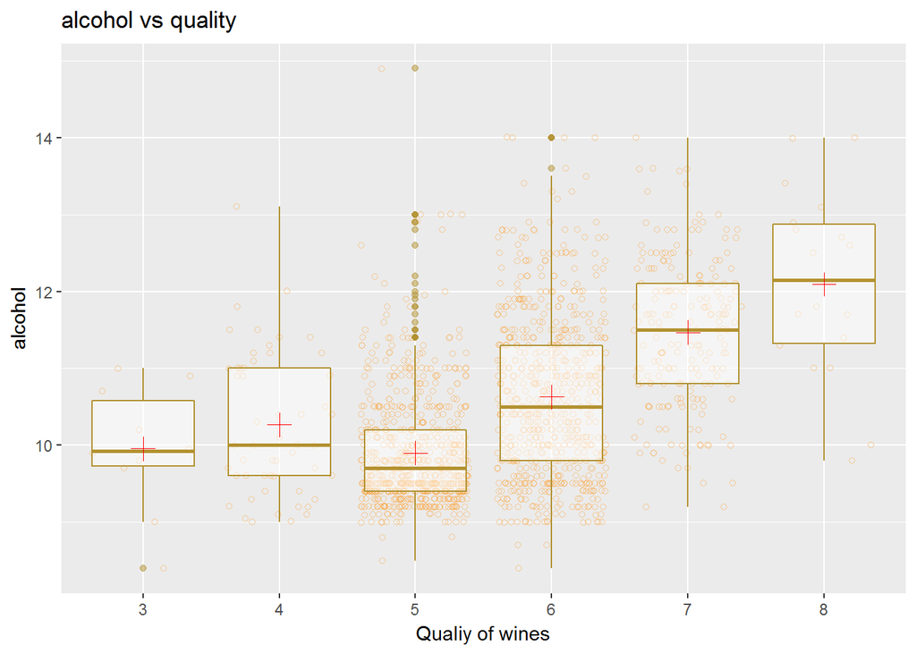

- It can bee seen from that as the mean alcohol content increases the quality of alcohol increase .
- There is a slight dip in the alcohol content for wines with rating of 5 when compared with 4 - rated wines.
- There is a huge difference in the mean alcohol content for alcohols with ratings of 7 and 8. It almost follows a very linear trend for wines with ratings of 6 and above.

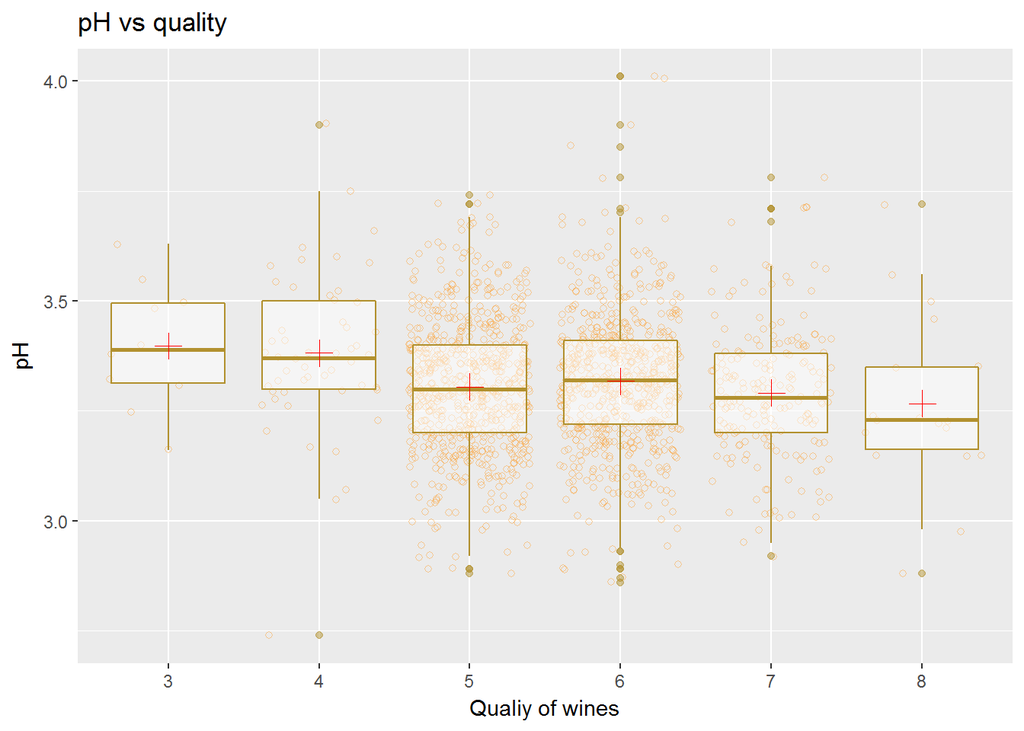

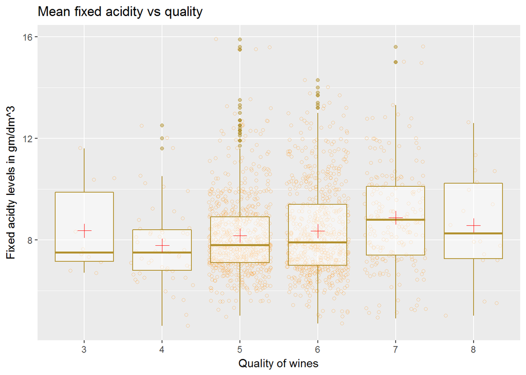

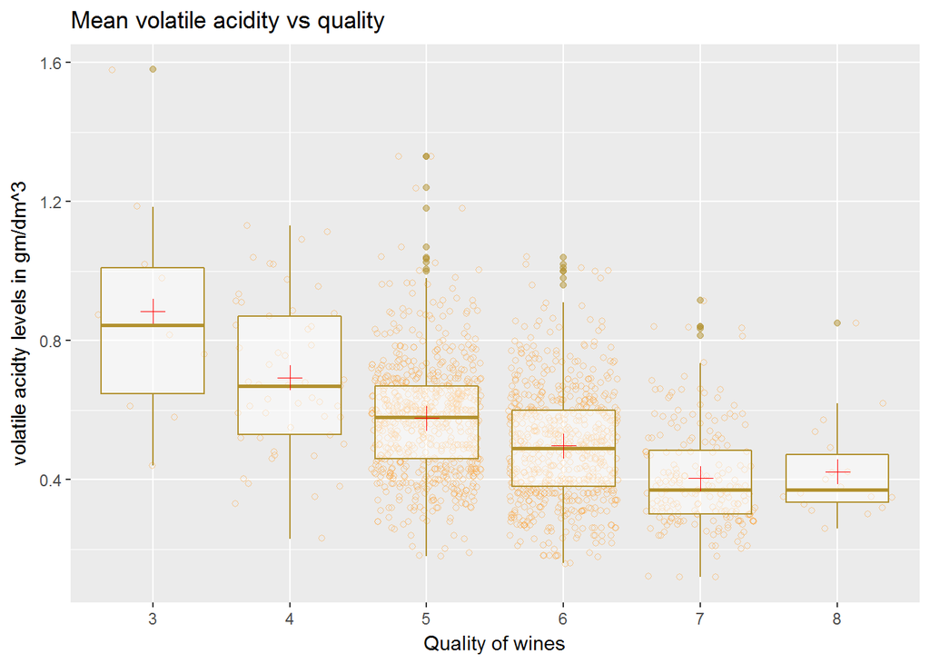

- It can be interepreted from the above graph that as the wine quality increases there is a fall in the mean volatile acid content.
- There is only a slight uptick in the mean volatile acid content for wines with quality rating of 8 as compared to that of wines with rating of 7.
- Let’s see how citric acid content affects the quality of wine

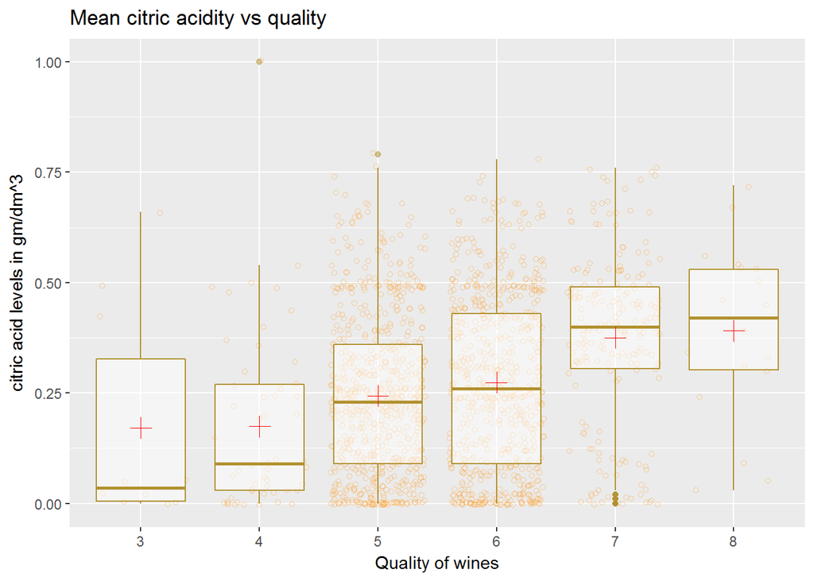

- As seen from the correlation plot where there is a weak positive correlation between the citic acid and quality of wines.
- The same can be noticed in the above plot also, where as the wine quality increases the citric acid content also increases.
- The affect of citric acid is almost linear for wines with quality ratings of 4 through 7.
- There is a very little uptick for mean value of citric acid for wines with quality rating of 8 when compared with wines with quality rating of 7.

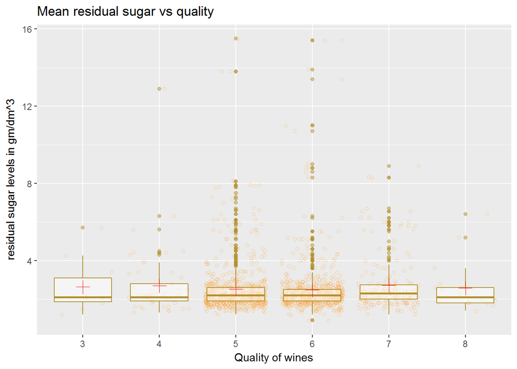

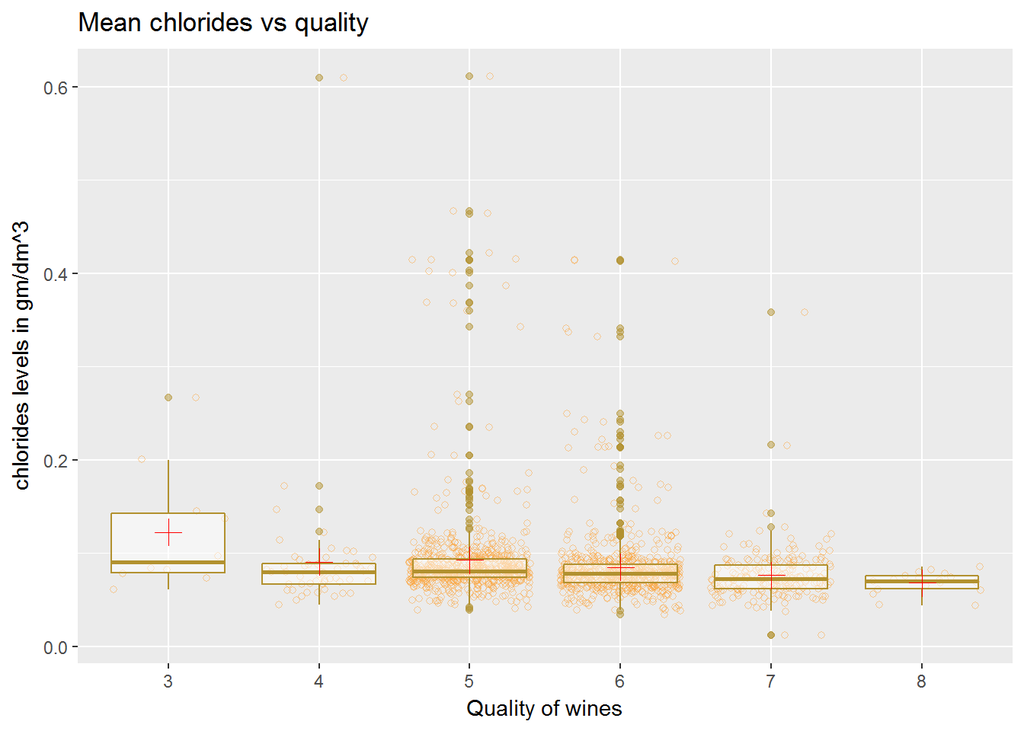

- As seen from the correlation plot there is a weak negative correlation between Quality of wines and Chlorides.In this plot it can be seen that mean value of chlorides is gradually decreasing for as the wine qualities increase.

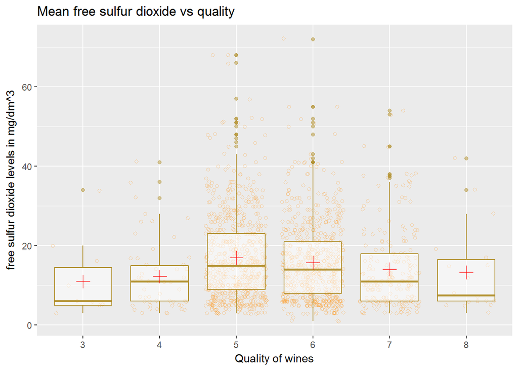

- Mean value of Free sulphur dioxide is highest for the wines with quality ratings of 5 and for all other high rated wines there is a fall in the amount of mean free sulphur dioxide. This value is lowest for the wines with quality rating of 3.

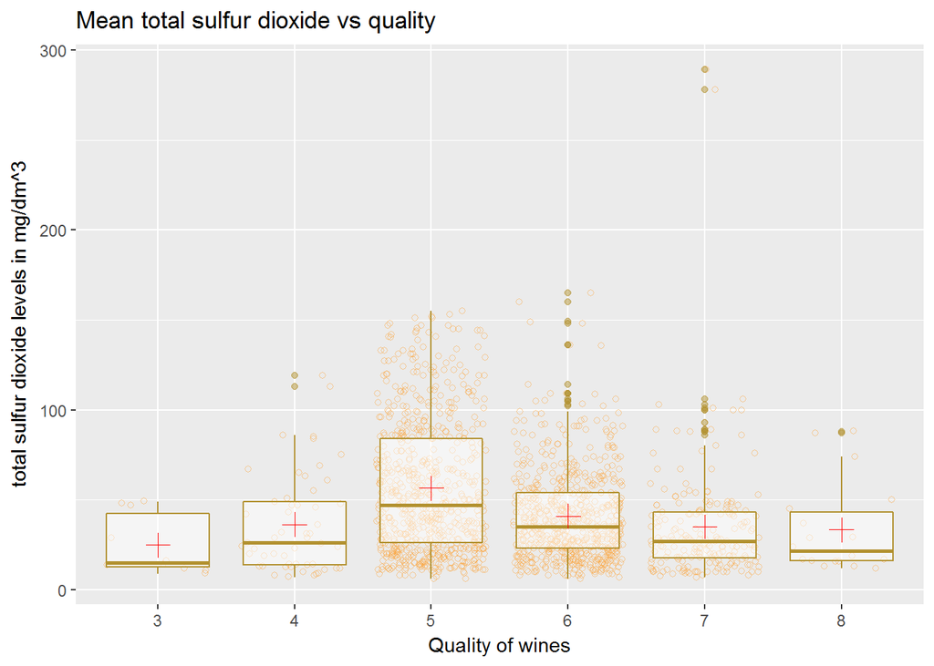

- Mean value of total sulfur dioxide follows the same trend as free sulfur dioxide , it is highest for the wines with quality ratings of 5 and for all other high rated wines there is a fall in the amount of mean total sulphur dioxide.
- This value is lowest for the wines with quality raing of 3.

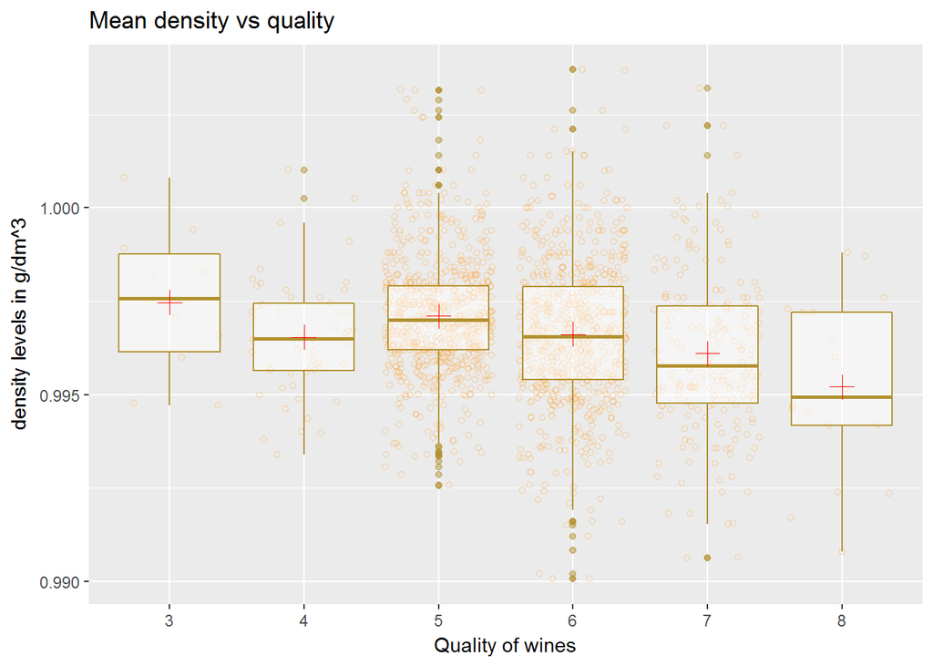

- Density of alcohol is lower than the density of water and as we have seen earlier that higher the quality wines have greater mean alcohol content. Hence in this plot where we compare the mean density wrt. qulaity of wines , there is a gradual fall in the density levels (as the aclohol content is higher) as the quality of wine increases.

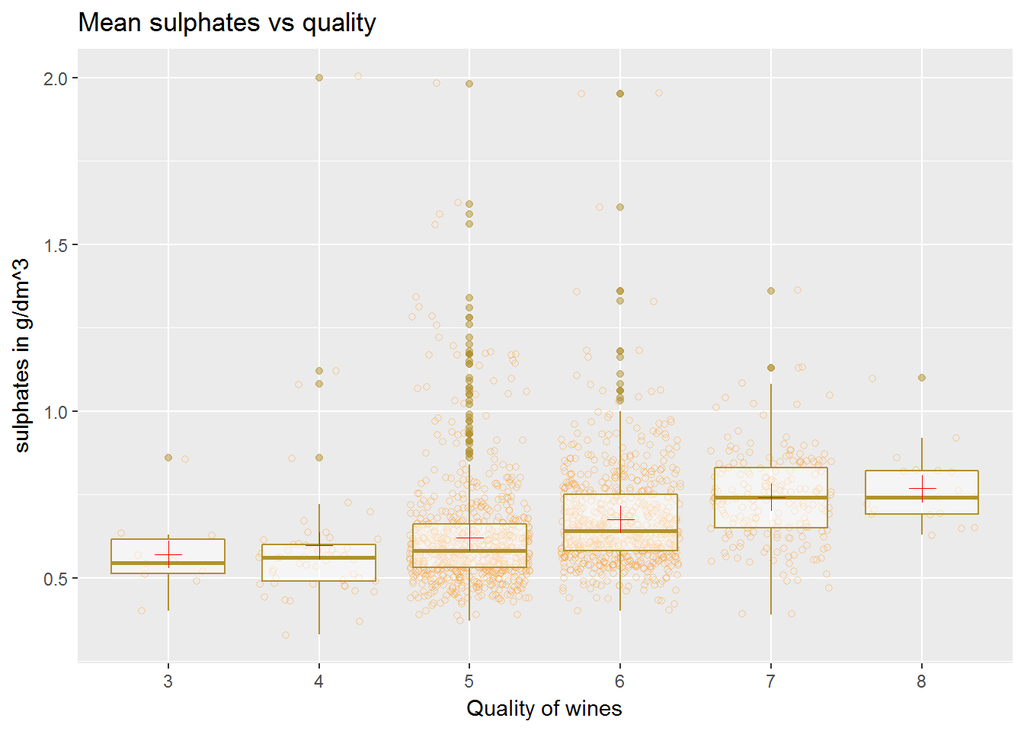

*From the above plot it can be seen that the mean sulphates content is constantly increaing as the quality rating increases. In the correlation plot also it can be seen that there was a weak correlation between these two variables.

- Sulphate content is lowest for the wines with quality rating of 3 and is highest for the quality ratings of 8.
- Let’s check the volatile acidity, sulphates , citric acid and alcohol content with few box plots. For the box plots I will be using the quality_category which is the categorical variable that I have created.

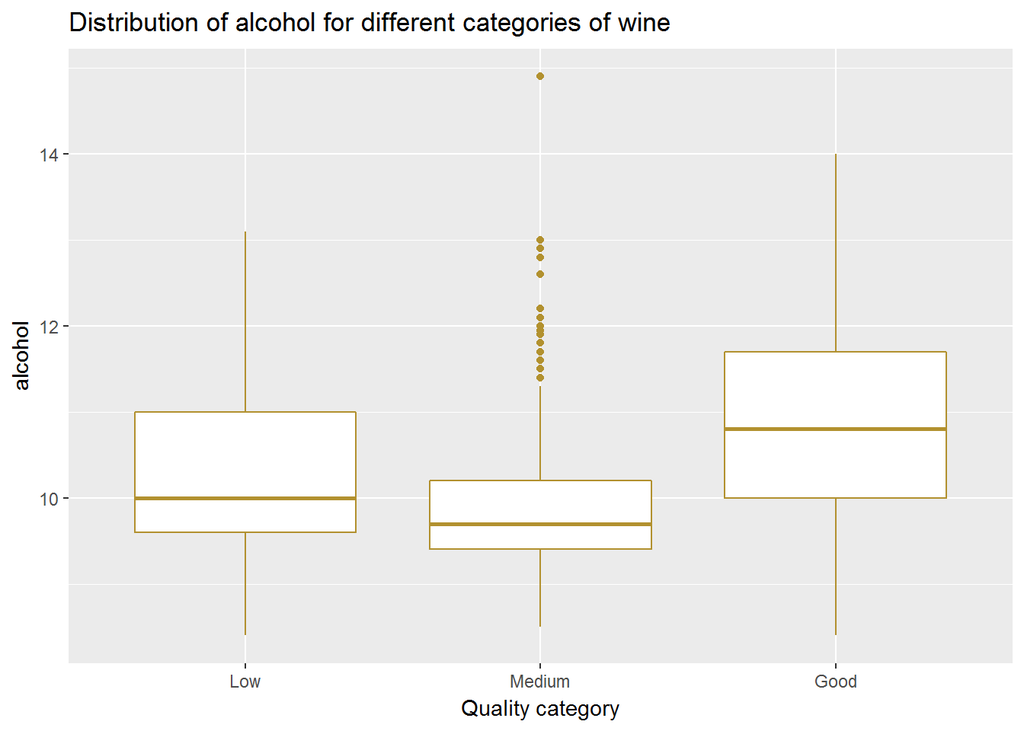

- It can be seen from the above plot that the median alcohol content for low quality wine is higher than the medium quality wine.
- The median alcohol content of Good quality wine is significantly higher than the other two categories.
- There are many outliers for the Medium quality wine in terms of alcohol content.

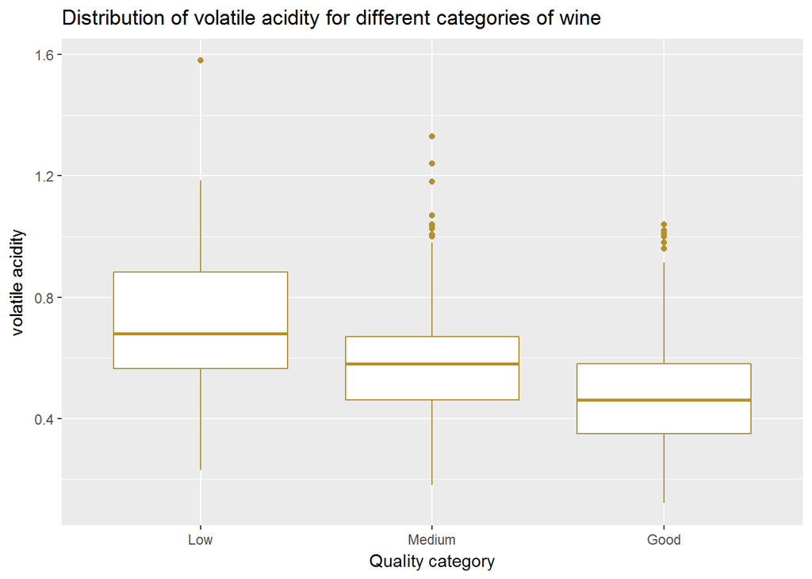

- As expected the median volatile acid content is low as the quality increases. Good quality wines have the least volatile acid content. There are many outliers for the medium category of wines.

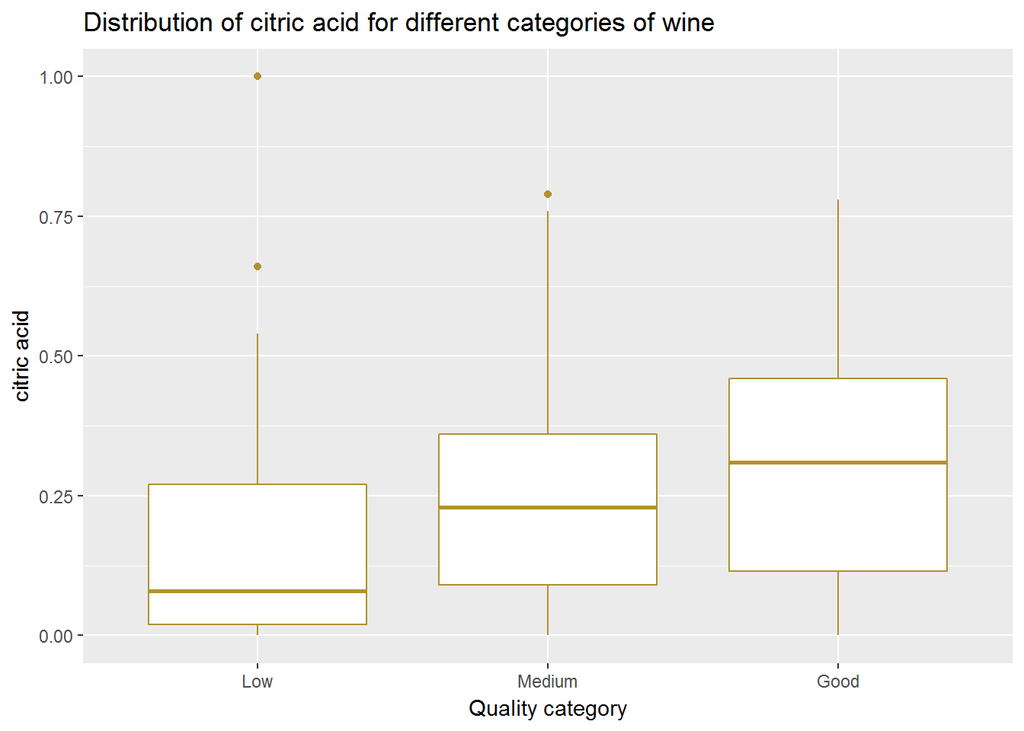

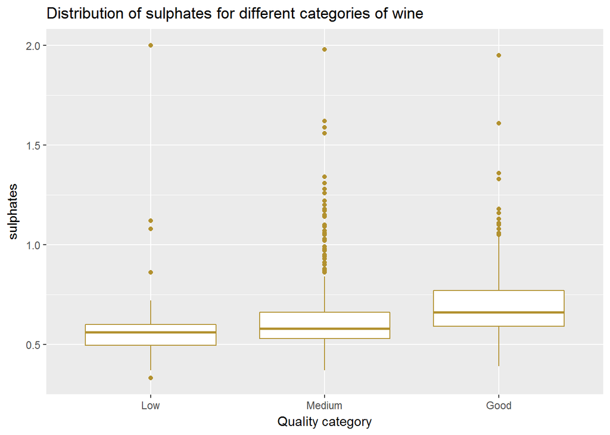

- Distribution of sulphates also shows that as the quality increase the median value of sulphates also increases in the wine. There are outliers for sulphates for each of the categories.

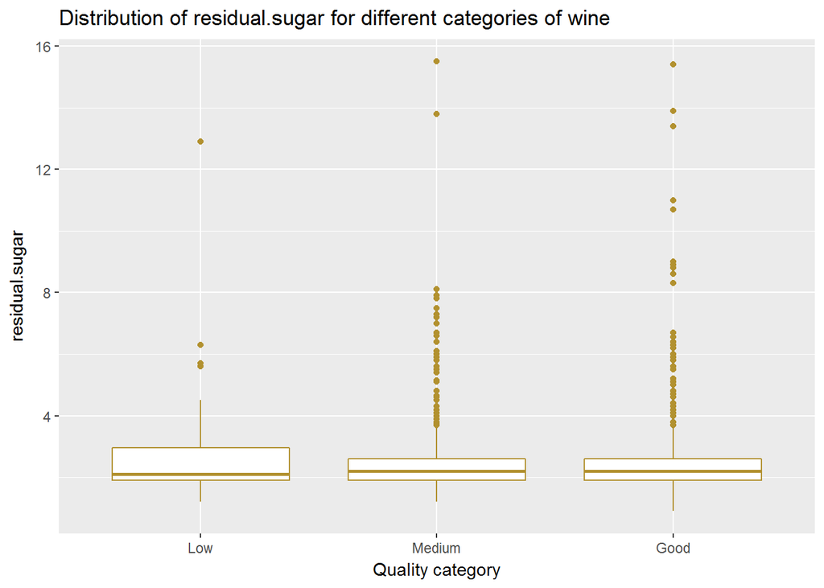

- From the above plot it can be seen that there is no significant difference in the median residual sugar content for each category.

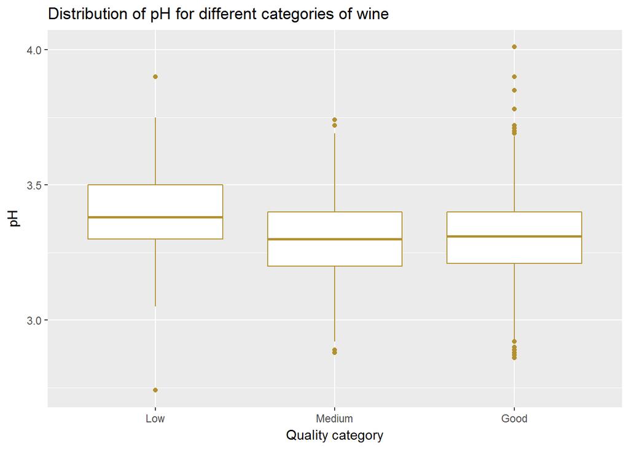

- pH value of the low quality wines is higher than the other two categories of quality of wines. Medium category has a quality which is slightly less than the Good quality wines.

**Let’s create a model which will predict Quality of wines based on the alcohol content.**

```
##
## Call:
## lm(formula = quality ~ alcohol, data = red_df)
##
## Residuals:
##     Min      1Q  Median      3Q     Max
## -2.8442 -0.4112 -0.1690  0.5166  2.5888
##
## Coefficients:
##             Estimate Std. Error t value Pr(>|t|)
## (Intercept)  1.87497    0.17471   10.73   <2e-16 ***
## alcohol      0.36084    0.01668   21.64   <2e-16 ***
## ---
## Signif. codes:  0 '***' 0.001 '**' 0.01 '*' 0.05 '.' 0.1 ' ' 1
##
## Residual standard error: 0.7104 on 1597 degrees of freedom
## Multiple R-squared:  0.2267, Adjusted R-squared:  0.2263
## F-statistic: 468.3 on 1 and 1597 DF,  p-value: < 2.2e-16
```

- As seen the above model has R squared value of 0.2263 which means that this alcohol can describe only 22.63 % of variance in quality.
- Since in our dataset the quality variable is more like a categorical variable which has a discrete value. Linear model creation may not be the correct way to build a model. Hence we have a very low R-squared value for this model.
- A classification model can be built to predict the correct quality value .

## 2.1 Talk about some of the relationships you observed in this part of the investigation. How did the feature(s) of interest vary with other features in the dataset?

- In this section I did some bi variate analysis and found out that quality is moderately positively correlated with alcohol content.
- I have also noticed that quality is moderately correalted with volatile acidity.
- I have created a linear model to predict the quality using alcohol content and it explains 22.63% variance in quality.
- Red wines with high levels of citric acid seem to have better quality ratings.

## 2.2 Did you observe any interesting relationships between the other features (not the main feature(s) of interest)?

- It can be noted that mean sulphates and mean citric acid have a positive impact on the quality of wines.
- There is an increase in the mean sulphate and citric acid content as the quality of wine increases.
- Also, Density of the wine decreases as the quality of wine rating increases.

## 2.3 What was the strongest relationship you found?

- Strongest poitive correlation was between fixed acidity and Citric acid , density and fixed acidity, and total sulfur dioxide and free sulfur dioxide.
- Strongest negative correlation was between pH and fixed acidity , citric acid and pH and Density and alcohol.

# 3 Multivariate Plots Section

**Let’s create few multi variate plots**

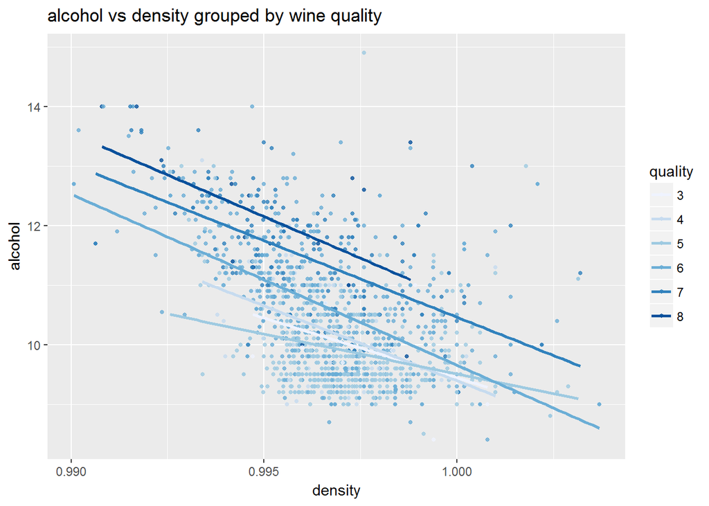

- In the above plot I am comparing alcohol content vs density and each point is denoted by the quality of the alcohol.
- It can be noticed that there is an inverse relationship between alcohol and density by looking at the regression line. It be seen that most of the 5 and 6 quality wines are around the mean density and mean alcohol range.
- As per the correaltion plot higher the alcohol content higher should be the rating. But here in this plot it can be seen that the highest alcohol content is for the wine with rating of 5 and it has an alcohol content of almost 15.
- There are few wines with ratings of 6 and above which have an alcohol content of 14.
- Also, there are few wines with low density and high alcohol content and these wines are having quality rating of 6 and above.
- The highest density wine and the lowest density wine has quality rating of 6.

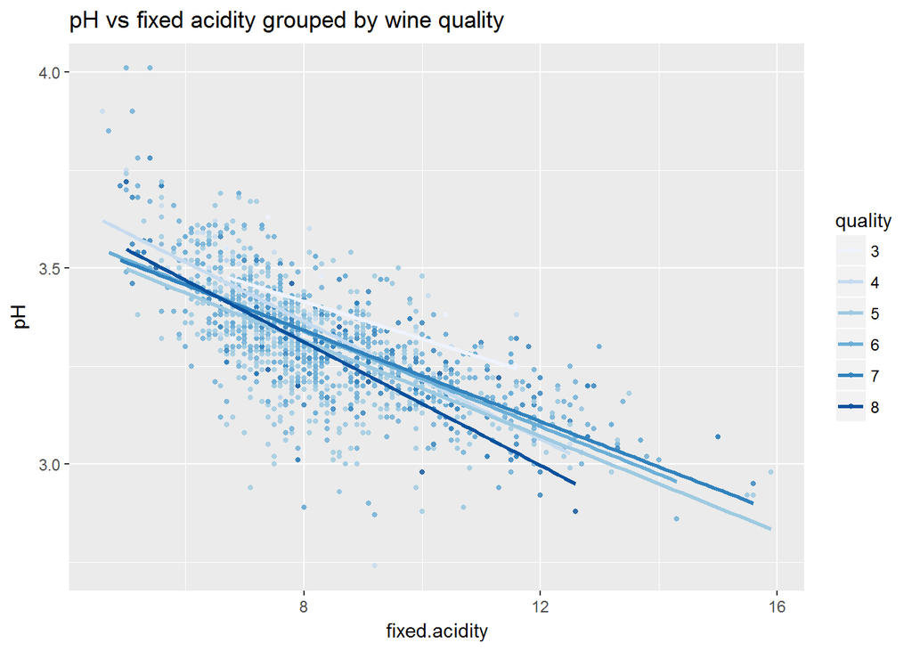

- There is an inverse relationship betwen pH and Fixed acidity. It is quite obvious by looking at the inverse slope of the regression line.
- Wines with quaity of 6 are having highest pH and hence the lowest acidty levels.
- There are wines with quality ratings of 5 with highest acidty.
- There is a wine of quality 4 which has a very low pH value and has acidity level of around 9.

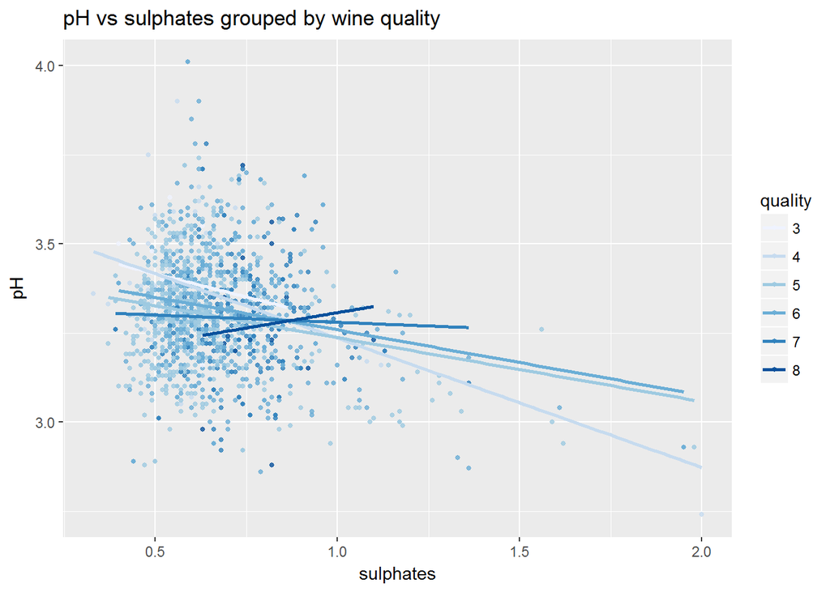

```
## red_df$quality: 3
##    Min. 1st Qu.  Median    Mean 3rd Qu.    Max.
##   6.700   7.150   7.500   8.360   9.875  11.600
## --------------------------------------------------------
## red_df$quality: 4
##    Min. 1st Qu.  Median    Mean 3rd Qu.    Max.
##   4.600   6.800   7.500   7.779   8.400  12.500
## --------------------------------------------------------
## red_df$quality: 5
##    Min. 1st Qu.  Median    Mean 3rd Qu.    Max.
##   5.000   7.100   7.800   8.167   8.900  15.900
## --------------------------------------------------------
## red_df$quality: 6
##    Min. 1st Qu.  Median    Mean 3rd Qu.    Max.
##   4.700   7.000   7.900   8.347   9.400  14.300
## --------------------------------------------------------
## red_df$quality: 7
##    Min. 1st Qu.  Median    Mean 3rd Qu.    Max.
##   4.900   7.400   8.800   8.872  10.100  15.600
## --------------------------------------------------------
## red_df$quality: 8
##    Min. 1st Qu.  Median    Mean 3rd Qu.    Max.
##   5.000   7.250   8.250   8.567  10.225  12.600
```

**five number summary of fixed acidity for each quality of wine**